# Trading and investment account summary

# For 2020-08-11

Summary text: The equity value of my live trading portfolio changed by -3.96 % (US$ -1326.29 ) from US$ 33481.3 to US$ 32155.01 today ( 2020-08-11 ). The trading proceeds in my live account were US$ 210.65 . The book proceeds in my portfolio changed from US$ 1943.21 to US$ 406.26

## Portfolio

The below table shows the current positions in the live account as well as their current and total performance. “book_proceed” indicates the unrealized profit in that position.

| symbol | close | closePerc | Total_Change_close | entry_price | position | position_size | entry_position | totalPerc | book_proceed | sector |
| --- | --- | --- | --- | --- | --- | --- | --- | --- | --- | --- |
| BRK.B | 212.60 | 0.03 | 3 | 195.40 | 50 | 10630.00 | 9770.15 | 8.09 | 859.85 | Finance |
| SEAS | 18.10 | 1.12 | -93 | 18.20 | -465 | -8416.50 | -8464.26 | 0.57 | 47.76 | Consumer Services |
| EZA | 36.47 | 0.4 | -29 | 38.54 | -200 | -7294.00 | -7708.00 | 5.68 | 414 | Miscellaneous |
| KWEB | 66.65 | -0.91 | -51.85 | 70.04 | 85 | 5665.25 | 5953.68 | -5.09 | -288.43 | Miscellaneous |
| TSLA | 1374.00 | -3.17 | -135 | 1405.56 | 3 | 4122.00 | 4216.67 | -2.3 | -94.67 | Consumer Durables |
| CAKE | 26.99 | 2.51 | 99 | 23.15 | 150 | 4048.50 | 3472.28 | 14.23 | 576.22 | Consumer Services |
| SQ | 138.25 | -0.72 | -25.12 | 141.33 | 25 | 3456.38 | 3533.37 | -2.23 | -76.99 | Technology Services |
| JWN | 16.89 | -0.06 | -2 | 14.85 | 200 | 3378.00 | 2969.98 | 12.08 | 408.02 | Retail Trade |
| INDA | 32.86 | -0.67 | -22 | 33.05 | 100 | 3286.00 | 3304.99 | -0.58 | -18.99 | Miscellaneous |
| MIK | 8.08 | -2.59 | -86 | 8.51 | 400 | 3232.00 | 3405.05 | -5.35 | -173.05 | Retail Trade |
| SLV | 23.33 | -13.59 | -495.45 | 22.13 | 135 | 3149.55 | 2988.17 | 5.12 | 161.38 | Miscellaneous |
| WPM | 49.22 | -6.73 | -213 | 55.66 | 60 | 2953.20 | 3339.79 | -13.09 | -386.59 | Non-Energy Minerals |
| LMND | 62.75 | -6.86 | -184.8 | 78.07 | 40 | 2510.00 | 3122.85 | -24.42 | -612.85 | Finance |
| TPR | 15.53 | 0.58 | 13.5 | 14.67 | 150 | 2329.50 | 2201.24 | 5.51 | 128.26 | Retail Trade |
| V | 197.80 | 0.46 | 9.1 | 194.66 | 10 | 1978.00 | 1946.64 | 1.59 | 31.36 | Finance |
| SWKS | 141.34 | -1.53 | -21.9 | 131.85 | 10 | 1413.40 | 1318.50 | 6.71 | 94.9 | Electronic Technology |
| LUV | 35.30 | 0.89 | 12.4 | 36.08 | 40 | 1412.00 | 1443.30 | -2.22 | -31.3 | Transportation |
| RVLV | 18.71 | -1.58 | -22.5 | 15.92 | 75 | 1403.25 | 1193.99 | 14.91 | 209.26 | Retail Trade |
| HD | 274.88 | 0 | 0 | 266.54 | 5 | 1374.40 | 1332.70 | 3.03 | 41.7 | Retail Trade |
| GDX | 39.06 | -7.9 | -117.25 | 43.89 | 35 | 1367.10 | 1536.25 | -12.37 | -169.15 | Miscellaneous |
| UNM | 19.34 | 3.04 | 39.9 | 19.50 | 70 | 1353.80 | 1365.00 | -0.83 | -11.2 | Finance |
| EPHE | 26.54 | 0.26 | -3.5 | 25.67 | -50 | -1327.00 | -1283.40 | -3.29 | -43.6 | Miscellaneous |
| PPLT | 88.32 | -5.06 | -70.55 | 89.44 | 15 | 1324.80 | 1341.55 | -1.26 | -16.75 | Miscellaneous |
| GOLD | 26.25 | -8.6 | -123.5 | 27.48 | 50 | 1312.50 | 1373.75 | -4.67 | -61.25 | Non-Energy Minerals |
| CRUS | 63.52 | -0.5 | -6.4 | 71.60 | 20 | 1270.40 | 1432.10 | -12.73 | -161.7 | Electronic Technology |
| UPWK | 13.96 | -3.59 | -36.92 | 14.48 | 71 | 991.16 | 1028.24 | -3.74 | -37.08 | Technology Services |
| PALL | 197.33 | -5.36 | -55.9 | 219.68 | 5 | 986.65 | 1098.40 | -11.33 | -111.75 | Miscellaneous |
| IAU | 18.28 | -5.38 | -52 | 19.30 | 50 | 914.00 | 965.00 | -5.58 | -51 | Miscellaneous |
| HLT | 87.07 | 1.02 | -8.8 | 74.54 | -10 | -870.70 | -745.40 | -14.39 | -125.3 | Consumer Services |
| PRU | 70.72 | 1.68 | 11.7 | 71.74 | 10 | 707.20 | 717.40 | -1.44 | -10.2 | Finance |
| ILMN | 341.28 | -3.42 | -24.14 | 346.12 | 2 | 682.56 | 692.24 | -1.42 | -9.68 | Health Technology |
| FIZZ | 62.00 | 1.29 | 7.9 | 68.20 | 10 | 620.00 | 682.00 | -10 | -62 | Consumer Non-Durables |
| NFLX | 466.63 | -3.39 | -16.37 | 486.00 | 1 | 466.63 | 486.00 | -4.15 | -19.37 | Consumer Services |
| QQQ | 265.21 | -1.88 | -5.07 | 258.76 | 1 | 265.21 | 258.76 | 2.43 | 6.45 | Miscellaneous |

| symbol | close | closePerc | Total_Change_close | entry_price | position | position_size | entry_position | totalPerc | book_proceed | sector |
| --- | --- | --- | --- | --- | --- | --- | --- | --- | --- | --- |
| Summary | NA | NA | -1705.52 | NA | 2603 | 86511.64 | NA | 0.47 | 406.2638 | NA |

[interactive chart not shown]

The performance of my live stock portfolio/trading account vs. my paper trading account and the benchmark ‘SPY’, the US large cap stock market index ETF in percent since June 09 2020.

[interactive chart not shown]

This plot shows a summary of the trading activity on that day. Above 0 is a gain, below is a loss. TRUE indicated live trading account, FALSE is paper trading. A buy side trade is a closed short sale trade and sell side trade is a closed long trade.

[interactive chart not shown]

My current portfolio sorted by sectors. The plot reads clock-wise. Positions below 0 are short positions. Clicking a slice of the pie chart directs to marketwatch.com for further information.

[interactive chart not shown]

These two plots indicate the composition of my portfolio and the change of it over the past week.

[interactive chart not shown]

The inner circle is Monday, the outer circle is Friday.

[interactive chart not shown]

The colors in this plot indicate the daily percentage change of each stock in my portfolio.

[interactive chart not shown]

I classified the stocks in my portfolio by sector. The area represents the size of the position in the portfolio. Long postions

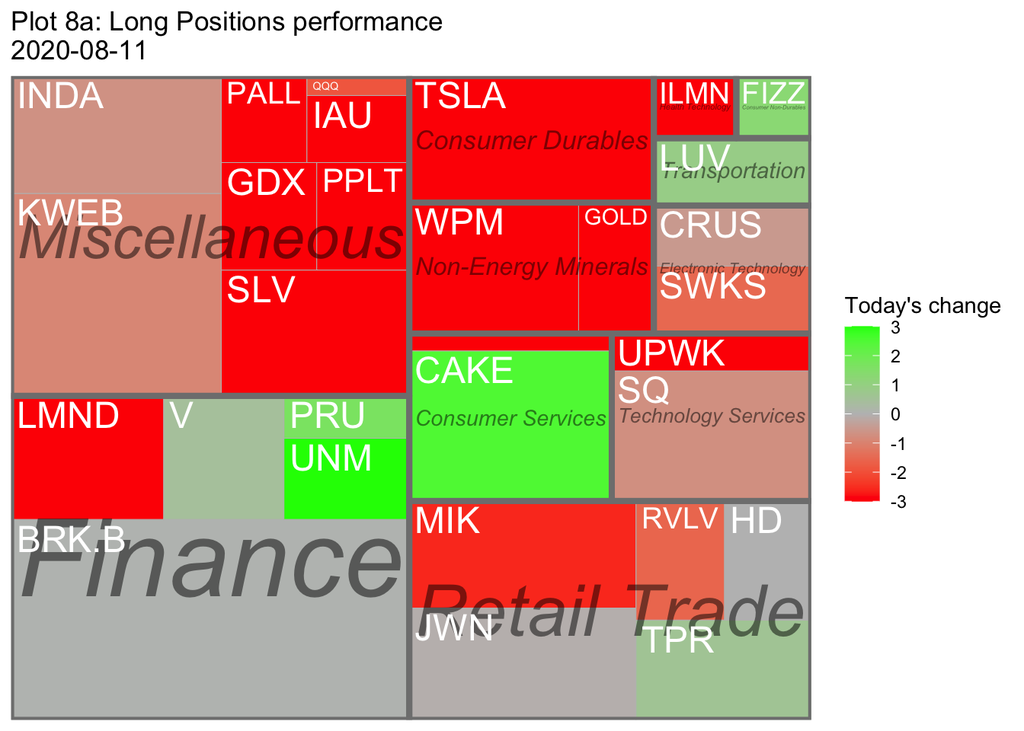

Short postions

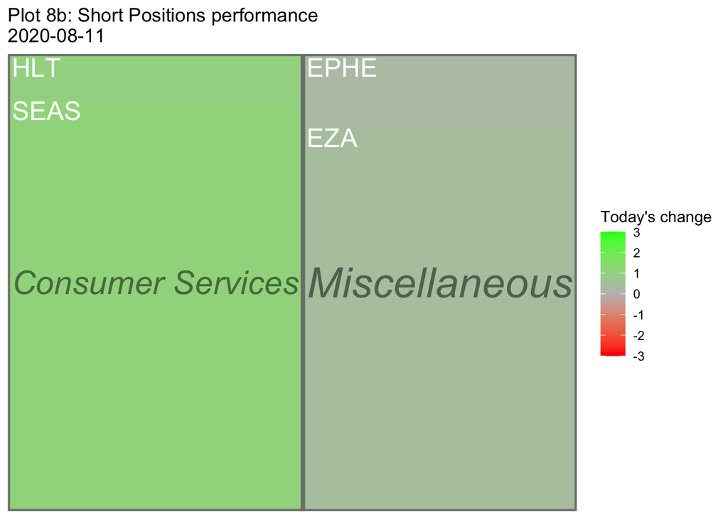

S&P 500 stocks colored by last day performance.

Outliers skew the colors, making the other stocks look pale. I restricted the colors to max of 3 and -3% change. Every stock having higher or lower than 3% change has the same color.

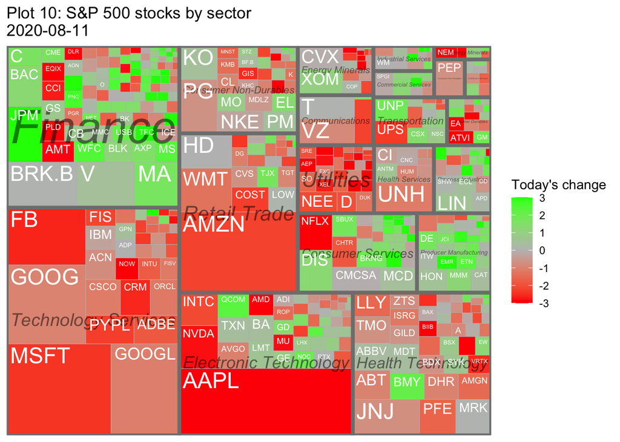

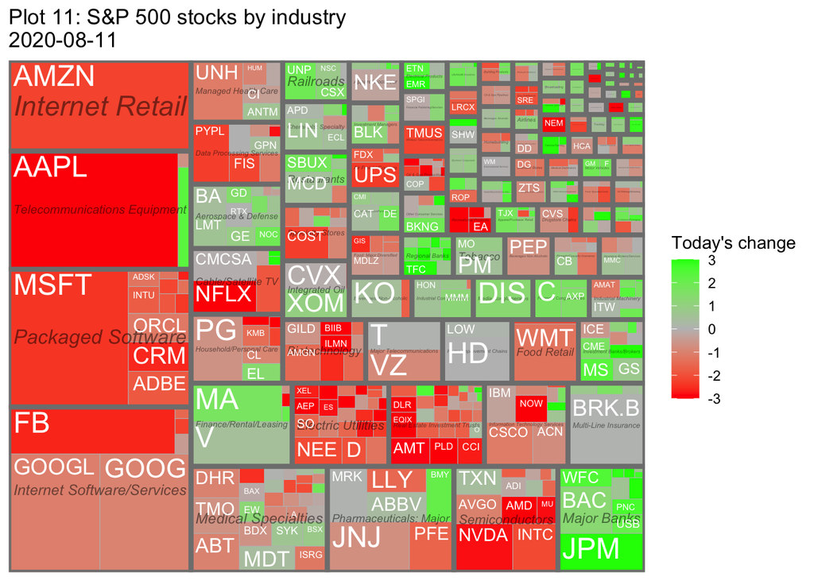